# Operações Básicas com o R

Análise de Dados Financeiros e Econômicos com o R

Marcelo S. Perlin

EA-UFRGS

20/08/2026

# Funcionamento do R e RStudio

## Como o R e RStudio funciona?

- Um *script* automatiza a análise de dados, produzindo algo no final, geralmente uma tabela ou uma figura
- Códigos serão inseridos e salvos em um *script* com extensão .R (ex. 01_run-research.R)
- Como um compilado de instruções em sequência, o *script* irá rodar **sempre** da mesma forma
- O código pode ser reaproveitado em projetos futuros

## Explicando a Tela do RStudio

[figure not shown]

A tela do RStudio

## Passos iniciais

- uma sessão do R é inicializada com o RStudio
- na execução, código é lido de cima para baixo;
- símbolo `<-` ou `=` define objetos na sessão do R
- cada objeto possui métodos diferentes
- função são métodos aplicados a objetos, tendo entradas e uma saída

## Seu primeiro *Script*

Digite e execute os seguintes comandos em um novo *script* do R:

```r
# Isso é um comentário (não roda nada)
x <- 1
y <- "meu lindo texto em português"

# mostre o valor do x
print(x)

# apresente um gráfico
plot(1:10)
```

**Atalhos para rodar código**

**control + shift + s**

executa o arquivo atual sem eco no console;

**control + shift + enter**

executa o arquivo atual com eco;

**control + enter**

executa a linha selecionada;

**alt + -**

insere `<-` (com espaços);

**control + shift + m**

insere o operador pipe `|>`;

**control + shift + c**

comenta ou descomenta as linhas selecionadas;

**control + .**

busca rápida de funções e arquivos no projeto;

## Seu segundo *script*

Digite os seguintes comandos em um novo *script* do R:

```r
# carregue pacotes
library(datasets)

# busque tabela
df <- datasets::chickwts

# verifique dados
print(df)

# adicione nova coluna
df$nova_coluna <- paste0("Linha ", 1:nrow(df))

# salve em arquivo temporário (ou na pasta do projeto)
write.csv(df, fs::file_temp(ext = ".csv"))
```

# Objetos no R

## Como obter ajuda

- `?função` ou `help(função)` abre a documentação oficial de uma função (ex.: `?readr::read_csv`)
- `??termo` busca um termo em todos os pacotes instalados
- `args(função)` mostra os argumentos esperados e `str(objeto)` mostra a estrutura de um objeto
- `View(objeto)` abre um objeto em uma aba interativa do RStudio
- Ao receber um erro, leia a mensagem completa, procure o trecho da mensagem no Google/IA e teste as funções isoladamente

## Tipos de objetos

No R, **tudo é um objeto, e cada tipo de objeto tem suas propriedades**.

```r
# numeric
x <- 1 # unique value
x <- 1:10 # sequence
x <- c(1, 4.1, 6.5, 7) # vector
x <- c(1, 1:10, 99) # combined vector
x <- runif(100) # 100 random numbers
x <- seq(1, 10, by = 2)

# Date
my_date <- as.Date("2022-01-05")
today <- Sys.Date()

# character
y <- 'text' # simples text
y <- c('my text 1', 'my.text2') # vector of texts

# logical
l <- TRUE
l <- FALSE
l <- c(TRUE, FALSE)

# dataframe (tabela)
df <- data.frame(x = 1:10,
                 z = paste0('linha ', 1:10))
```

## O Formato Internacional

- **decimal:** O decimal no R é definido pelo ponto (.), tal como em `2.5` e não vírgula, como em `2,5`.
- evite **caracteres latinos** ao máximo. Nos textos (objeto de caracteres), é possível utilizá-los desde que a codificação do objeto esteja correta (UTF-8 ou Latin1).

**formato das datas:** as datas no R são formatadas de acordo com o padrão [ISO 8601](https://www.iso.org/iso-8601-date-and-time-format.html), seguindo o padrão `YYYY-MM-DD`

# Pacotes do R

## Introdução a pacotes

> Pacotes são módulos **gratuitos**, desenvolvidos por outros usuários, e podem ser instalados e usados livremente em seu computador.
- O R possui hoje em torno de 24708 pacotes à disposição dos usuários
- O repositório oficial de pacotes é o [CRAN (The Comprehensive R Archive Network)](https://cran.r-project.org/), mas alguns pacotes estão disponíveis no [Github](https://github.com/)
- Cada pacote é nada mais que um conjunto de arquivos, copiado para sua pasta local e compilado localmente conforme necessidade. No meu caso (comando `.libPaths()`), a pasta é: /home/msperlin/R/x86_64-pc-linux-gnu-library/4.6
- O [task views](https://cran.r-project.org/) é uma ótima fonte para estudar potenciais pacotes em uma determinada área de conhecimento
- **DICA: é extremamente provável que o método que pretende usar em seu artigo/dissertação/tese esteja disponível em um pacote**

## Instalando Pacotes

- Pacotes do CRAN são instalados com comando `install.packages()`

```r
# install pkg readr
install.packages('readr')
```

- Pacotes do Github são instalados com `remotes::install_github()` ou `pak::pkg_install()`:

```r
# install ggplot2 from github using remotes or pak
remotes::install_github("hadley/ggplot2")
# ou com pak:
# pak::pkg_install("hadley/ggplot2")
```

## Pacote `pak`

> Pacote `pak` é uma versão **moderna** de `utils::install.packages()` para a instalação de pacotes do R, que otimiza a instalação de pacotes e suas dependências.
- Baixa e compila múltiplos pacotes simultaneamente
- Resolução inteligente de dependências
- Sintaxe unificada para múltiplas fontes: Instala de diversas origens usando o mesmo comando (`pak::pkg_install()`): CRAN/Github/Bioconductor
- Executa o processo de build em uma sessão de R separada, evitando conflitos com pacotes já carregados na sua sessão atual.
- Dependências de sistema automáticas: No Linux, identifica e instala (ou instrui como instalar) as bibliotecas C/C++ necessárias no sistema operacional.
- Feedback visual claro: Interface mais limpa, indicando o progresso, tempo restante e o plano de resolução antes de aplicar as mudanças.

## Ambientes isolados no R

> No R, é possível criar ambientes isolados, com pacotes e versões específicas, para cada projeto. Isso evita conflitos de versões de pacotes entre projetos diferentes.
- Pacote `renv` permite criar ambientes isolados para cada projeto, com pacotes e versões específicas.
- Vantagens: conflitos de pacotes entre projetos diferentes são evitados, e é possível compartilhar o ambiente com outros usuários.
- Desvantagens: necessita da reinstalação dos pacotes a cada projeto.

## Exercício 1

1. Crie um novo *script* e rode:

```r
yvec <- c('text1', 'text2', 'text3', 'text4', 'text5', 'text6')
zvec <- paste0('text', 1:6)

print(yvec)
print(zvec)
```

`yvec` e `zvec` são iguais? Por que?

2. Pacote `fortunes` permite que o usuário **conte piadas** com o R. Instale o mesmo e execute a sua principal função `fortune()`. Qual é a piada contada?
3. Pacote `afedR3` foi construído baseado na versão em inglês do livro da disciplina. Instale o mesmo com o comando `remotes::install_github("msperlin/afedR3")` (ou `pak::pkg_install("msperlin/afedR3")`). Após isso, execute o código abaixo e descreva qual a finalidade do mesmo.

```r
# importe dados
f_df <- afedR3::data_path("CH04_ibovespa.csv")
df <- readr::read_csv(f_df)

# apresente a tabela
print(df)
```

4. Crie o vetor `v <- c(10, 20, "30")`. Verifique a sua classe com `class(v)`. O que acontece ao tentar executar `v + 5`? Como converter o vetor para numérico e realizar a operação?
5. Crie um projeto com ambiente de R isolado e refaça o exercício 3. O que mudou?

# Interagindo com o Sistema Operacional

## Operações mais comuns e importantes

- Mudança de diretório de trabalho
  - comandos `setwd()`/`getwd()`
  - DICA: uso de PROJETOS do RStudio automatiza essa tarefa no dia-a-dia
- Limpeza de memória:
  - comando `rm()` limpa a memória
  - reinicialização da sessão com *control + shift + f10*.
  - Caso necessário, force a limpeza da memória RAM (*garbage collection*) com `gc()`
- Listar arquivos e diretórios
  - comando `fs::dir_ls(PATH)`
  - o R possui uma pasta temporária, a qual pode ser usada nas mais diferentes operações. Para descobrir a sua, use a função `fs::path_temp()`. A minha é “/tmp/Rtmp9GmbQB”
- Apagar e remover diretórios
  - diversos comandos com pacote `fs`.

# Interagindo com a Internet

## Baixando Arquivos da Internet

- função `download.file` baixa arquivos da internet:

```r
# set link
link <- 'go.microsoft.com/fwlink/?LinkID=521962'
local_file <- fs::file_temp(ext = ".xlsx")

download.file(url = link,
              destfile = local_file)

df <- readxl::read_excel(local_file)

print(df)
```

## Interagindo com APIs

- acesse APIs da internet com `jsonlite::fromJSON()`
- exemplo: acesso o api do Banco Central do Brasil para importar taxas atuais de financiamento de veículos
- o operador pipe `|>` encadeia operações: a saída da esquerda é passada como primeiro argumento da função à direita

```r
url <- "https://www.bcb.gov.br/api/servico/sitebcb/historicotaxajurosdiario/TodosCampos?filtro=codigoSegmento%20eq%20%271%27%20and%20codigoModalidade%20eq%20%27401101%27%20and%20InicioPeriodo%20eq%20%272023-05-09%27"

df_taxas_auto <- jsonlite::fromJSON(url)[[1]]

df_taxas_auto |>
  gt::gt()
```

| Posicao | cnpj8 | Segmento | Modalidade | InstituicaoFinanceira | TaxaJurosAoMes | TaxaJurosAoAno |
| --- | --- | --- | --- | --- | --- | --- |
| 1 | 04452473 | Pessoa Física | Aquisição de veículos - Prefixado | BMW SA CFI | 1,18 | 15,11 |
| 2 | 02992446 | Pessoa Física | Aquisição de veículos - Prefixado | BANCO CNH INDUSTRIAL CAPITAL S.A | 1,26 | 16,27 |
| 3 | 28517628 | Pessoa Física | Aquisição de veículos - Prefixado | BCO PACCAR S.A. | 1,29 | 16,59 |
| 4 | 09313766 | Pessoa Física | Aquisição de veículos - Prefixado | CARUANA SCFI | 1,29 | 16,68 |
| 5 | 58017179 | Pessoa Física | Aquisição de veículos - Prefixado | BCO VOLVO BRASIL S.A. | 1,34 | 17,30 |
| 6 | 11417016 | Pessoa Física | Aquisição de veículos - Prefixado | SCANIA BCO S.A. | 1,36 | 17,55 |
| 7 | 59109165 | Pessoa Física | Aquisição de veículos - Prefixado | BCO VOLKSWAGEN S.A | 1,36 | 17,64 |
| 8 | 59274605 | Pessoa Física | Aquisição de veículos - Prefixado | BCO GM S.A. | 1,54 | 20,14 |
| 9 | 60814191 | Pessoa Física | Aquisição de veículos - Prefixado | BCO MERCEDES-BENZ S.A. | 1,57 | 20,61 |
| 10 | 33603457 | Pessoa Física | Aquisição de veículos - Prefixado | BCO RODOBENS S.A. | 1,60 | 20,99 |
| 11 | 62307848 | Pessoa Física | Aquisição de veículos - Prefixado | BCO RCI BRASIL S.A. | 1,61 | 21,11 |
| 12 | 04866275 | Pessoa Física | Aquisição de veículos - Prefixado | BANCO INBURSA | 1,62 | 21,33 |
| 13 | 03502961 | Pessoa Física | Aquisição de veículos - Prefixado | STELLANTIS FINANCIAMENTOS CFI | 1,68 | 22,17 |
| 14 | 30172491 | Pessoa Física | Aquisição de veículos - Prefixado | BANCO HYUNDAI CAPITAL BRASIL | 1,70 | 22,37 |
| 15 | 60746948 | Pessoa Física | Aquisição de veículos - Prefixado | BCO BRADESCO S.A. | 1,71 | 22,61 |
| 16 | 33136888 | Pessoa Física | Aquisição de veículos - Prefixado | BRB - CFI S/A | 1,76 | 23,24 |
| 17 | 03215790 | Pessoa Física | Aquisição de veículos - Prefixado | BCO TOYOTA DO BRASIL S.A. | 1,80 | 23,80 |
| 18 | 22639377 | Pessoa Física | Aquisição de veículos - Prefixado | SINOSSERRA S/A - SCFI | 1,80 | 23,90 |
| 19 | 28127603 | Pessoa Física | Aquisição de veículos - Prefixado | BCO BANESTES S.A. | 1,83 | 24,29 |
| 20 | 17167412 | Pessoa Física | Aquisição de veículos - Prefixado | FINANCEIRA ALFA S.A. - SCFI | 1,85 | 24,60 |
| 21 | 45437547 | Pessoa Física | Aquisição de veículos - Prefixado | SAFRA SCFI S.A. | 1,95 | 26,11 |
| 22 | 00000000 | Pessoa Física | Aquisição de veículos - Prefixado | BCO DO BRASIL S.A. | 1,97 | 26,33 |
| 23 | 60872504 | Pessoa Física | Aquisição de veículos - Prefixado | ITAÚ UNIBANCO HOLDING S.A. | 1,99 | 26,60 |
| 24 | 01852137 | Pessoa Física | Aquisição de veículos - Prefixado | BCO BRASILEIRO DE CRÉDITO S.A. | 1,99 | 26,62 |
| 25 | 31872495 | Pessoa Física | Aquisição de veículos - Prefixado | BCO C6 S.A. | 2,00 | 26,86 |
| 26 | 07707650 | Pessoa Física | Aquisição de veículos - Prefixado | SANTANDER SCFI S.A. | 2,06 | 27,64 |
| 27 | 00360305 | Pessoa Física | Aquisição de veículos - Prefixado | CAIXA ECONOMICA FEDERAL | 2,08 | 28,00 |
| 28 | 07207996 | Pessoa Física | Aquisição de veículos - Prefixado | BCO BRADESCO FINANC. S.A. | 2,11 | 28,41 |
| 29 | 04862600 | Pessoa Física | Aquisição de veículos - Prefixado | PORTOSEG S.A. CFI | 2,11 | 28,48 |
| 30 | 59588111 | Pessoa Física | Aquisição de veículos - Prefixado | BCO VOTORANTIM S.A. | 2,18 | 29,59 |
| 31 | 90400888 | Pessoa Física | Aquisição de veículos - Prefixado | BCO SANTANDER (BRASIL) S.A. | 2,31 | 31,47 |
| 32 | 03634220 | Pessoa Física | Aquisição de veículos - Prefixado | BCO HONDA S.A. | 2,45 | 33,76 |
| 33 | 60701190 | Pessoa Física | Aquisição de veículos - Prefixado | ITAÚ UNIBANCO S.A. | 2,46 | 33,83 |
| 34 | 10371492 | Pessoa Física | Aquisição de veículos - Prefixado | BCO YAMAHA MOTOR S.A. | 2,59 | 35,98 |
| 35 | 92874270 | Pessoa Física | Aquisição de veículos - Prefixado | BCO DIGIMAIS S.A. | 2,66 | 36,95 |
| 36 | 34991938 | Pessoa Física | Aquisição de veículos - Prefixado | SIMPALA S.A. CFI | 2,73 | 38,10 |
| 37 | 05676026 | Pessoa Física | Aquisição de veículos - Prefixado | CREDIARE CFI S.A. | 2,91 | 41,02 |
| 38 | 00411939 | Pessoa Física | Aquisição de veículos - Prefixado | FINAMAX S.A. CFI | 3,03 | 43,08 |
| 39 | 62232889 | Pessoa Física | Aquisição de veículos - Prefixado | BCO DAYCOVAL S.A | 3,12 | 44,52 |
| 40 | 59285411 | Pessoa Física | Aquisição de veículos - Prefixado | BANCO PAN | 3,18 | 45,62 |
| 41 | 92228410 | Pessoa Física | Aquisição de veículos - Prefixado | OMNI SA CFI | 3,43 | 49,85 |
| 42 | 05192316 | Pessoa Física | Aquisição de veículos - Prefixado | VIA CERTA FINANCIADORA S.A. - CFI | 3,77 | 55,94 |
| 43 | 05503849 | Pessoa Física | Aquisição de veículos - Prefixado | CLOUDWALK FINANCEIRA S.A. CFI | 3,95 | 59,11 |

# Ferramentas de produtividade do RStudio

## *Code completion*

- ative a ferramenta *code completion* com a tecla *tab*
- Serve para facilitar o encontro de:
  - nomes de objetos;
  - nome de pacotes;
  - nome de arquivos;
  - nomes de entradas em funções.

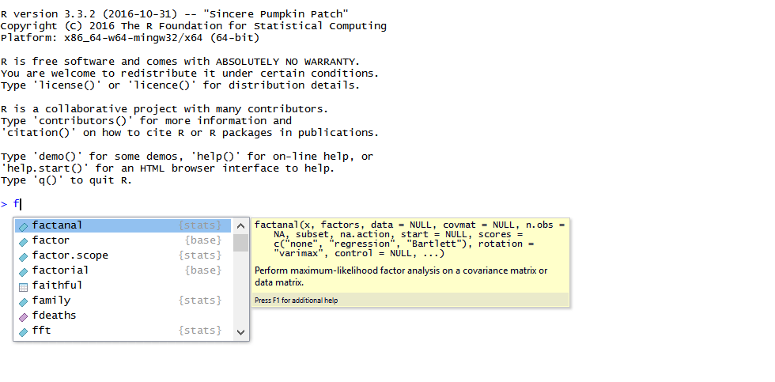

Uso do autocomplete para objetos

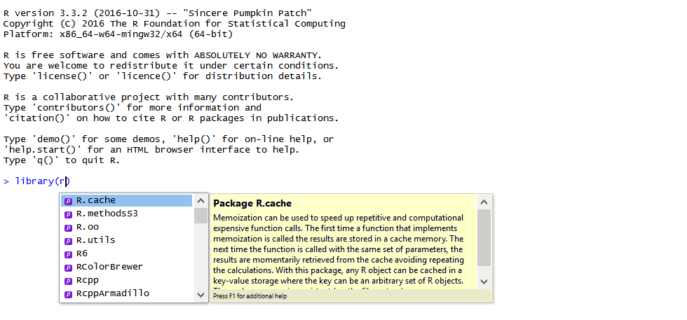

Uso do autocomplete para pacotes

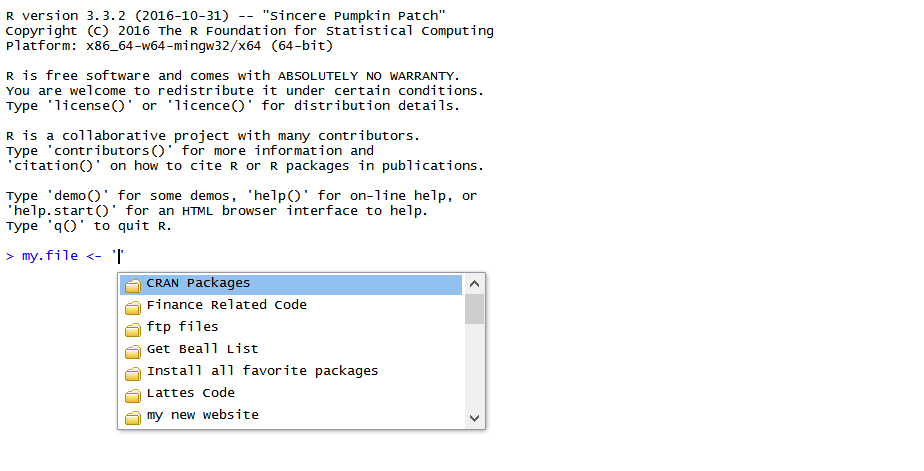

Uso do autocomplete para arquivos

## Exercícios 2 (1/2)

1. Utilize o R para baixar o arquivo compactado com o material do livro, disponível neste [link](https://www.msperlin.com/files/afedr-files/afedR-code-and-data.zip). Salve o mesmo como um arquivo na pasta temporária da sessão (veja função `fs::file_temp(ext = ".zip")`).
2. Utilize a função `unzip` para descompactar o arquivo baixado na questão anterior em uma pasta temporária (`fs::path_temp()`) e, após a operação, utilize a função `fs::file_delete()` para remover o arquivo zipado do computador. Quantos arquivos estão disponíveis no arquivo descompactado?
3. Toda vez que o usuário instala um pacote do R, os arquivos desse são armazenados localmente em uma pasta específica do computador. Utilizando os comandos `.libPaths()[1]` e `fs::dir_ls()`, liste todos os diretórios desta pasta. Quantos pacotes estão instalados nesta biblioteca?
4. No mesmo assunto do exercício anterior, liste todos os arquivos em todas as subpastas do diretório contendo os arquivos dos pacotes. Em média, quantos arquivos são necessários para cada pacote?

## Exercícios 2 (2/2)

5. Instale o pacote `GetTDData` no seu computador. Leia o manual do pacote (use `?GetTDData::get_yield_curve`) e utilize a função `GetTDData::get_yield_curve()` para baixar a curva de juros atual no sistema financeiro Brasileiro.
6. Utilizando o pacote `pak` (ou `remotes`), instale a versão de desenvolvimento do pacote `ggplot2` do repositório oficial do Github (`tidyverse/ggplot2`). Carregue o pacote usando `library(ggplot2)` e crie um gráfico de dispersão com dados aleatórios (`x = 1:10`, `y = rnorm(10)`).
7. **DESAFIO** - Utilizando sua capacidade de programação, verifique na sua pasta de usuário (`fs::path_home()`) qual subdiretório de primeiro nível possui o maior número total de arquivos (recursivamente). Apresente na tela as cinco pastas com maior número de arquivos.